# ARMA, ARIMA, and SARIMA Models

Michael Winton

## ARMA Models

The ARMA model is a stationary model, which means we will need to assume (and verify) that our data are a realization of a stationary process. Because regression can be used to break down a nonstationary model to a trend, seasonal components, and a residual series, it’s often reasonable to apply stationary models to the residuals from a time series regression.

A time series is called a mixed autoregressive moving average model of order $(p,q)$ if it is *stationary* and takes the form:

$$x_t = \phi_1 x_{t-1} + ... + \phi_p x_{t-p} + w_t + \theta_1 w_{t-1} + ... + \theta_q w_{t-q}$$
We can observe that the model includes a white noise component, an AR component, and a moving average component. This equation assumes the series has already been demeaned.

We can rewrite this equation in terms of backshift operators and simplify in order to get a very concise version of the equation.

$$x_t - \phi_1 x_{t-1} - ... - \phi_p x_{t-p} = w_t + \theta_1 w_{t-1} + ... + \theta_q w_{t-q}$$
$$x_t (1-\phi_1 B - ... - \phi_p B^p) = w_t (1 + \theta_1 B + ... + \theta_q B^q)$$
$$x_t (1-\phi_1 B - ... - \phi_p B^p) = w_t (1 + \theta_1 B + ... + \theta_q B^q)$$

$$\phi_p(B) x_t = \theta_q(B) w_t$$

Important points about an $ARMA(p,q)$ model:

- the process is *stationary* when absolute value of all roots of $\phi_p$ > 0
- the process is *invertible* when absolute value of all roots of $\theta_q$ > 0
- $AR(p)$ model is a special case where $q=0$
- $MA(q)$ model is a special case where $p=0$
- *Parsimony*: an ARMA model will often be more parameter-efficient that either AR or MA by themselves
- Sometimes we can simplify the equation if $\phi_p$ and $\theta_q$ share a common factor

If we wanted to accommodate a non-zero mean $\mu$, then we would add a constant term on the right-hand side: $\alpha = \mu (1-\phi_1 - ...- \phi_p)$:

$$x_t = \alpha + w_t +[ \phi_1 x_{t-1} + ... + \phi_p x_{t-p} ] + [\theta_1 w_{t-1} + ... + \theta_q w_{t-q}]$$

The equation for $\alpha$ can also be rearranged to show that the mean $\mu$ is stationary:

$$\mu = \frac{\alpha}{1-\phi_1 - ...- \phi_p}$$

### Transforming $ARMA(p,q)$ Model to an $MA(\infty)$ or $AR(\infty)$ Model

If we go back to the ARMA equation in terms of the backshift operator:

$$\phi_p(B) x_t = \theta_q(B) w_t$$

we see that we can rearrange it to get an MA process ($x_t$ as a function of $w_t$):

$$x_t = \frac {\theta_q(B)}{ \phi_p(B)} w_t \equiv \psi(B) w_t$$
Through expansion of $\phi_p(B)$ in the denominator as a geometric series, this becomes an $MA(\infty)$ model.

Likewise, we can rearrange to achieve an $AR(\infty)$ model ($w_t$ as a function of $x_t$):

$$w_t = \frac{ \phi_p(B)} {\theta_q(B)} x_t \equiv \pi(B) x_t$$

### Derivation of Second Order Properties

*Skipped. Terminology in async is completely inconsistent from slide to slide. It seems like it’s mainly used to derive an equation corresponding to the form of the ACF plot.*

### ACF and PACF plots for AR, MA, and ARMA Models

Reminder about the general properties of the ACF and PACF plots:

| Plot | AR(p) Model | MA(q) Model | ARMA (p,q) Model |
| --- | --- | --- | --- |
| ACF | Tails off | Abrupt cutoff after lag q | Tails off |
| PACF | Abrup.t cutoff after lag p | Tails off | Tails off |

Because the ACF for $ARMA(1,1)$ and $AR(1)$ only differ by a constant, it’s hard to use ACF plots to distinguish between the models. In an $AR(p)$ model, as $p$ approaches 1, the series gets more persistent. However, even with a smaller $p$, the addition of an $MA(q)$ component will also contribute to persistence.

We may be able to more easily distinguish (in some cases) from a PACF plot. Recall that the PACF plot for a $AR(p)$ model cuts off abruptly after $p$ lags; a PACF plot for an $ARMA(p,q)$ plot generally will take longer to tail off.

In practice, we will estimate several models and use AIC, BIC, or forecasting a test set to decide between them.

### Example: British Pound - NZ Dollar Exchange Rate

```r
df <- read.table('pounds_nz.dat', header=TRUE)
bpnz <- ts(df$xrate)
str(bpnz)
```

```
##  Time-Series [1:39] from 1 to 39: 2.92 2.94 3.17 3.25 3.35 ...
```

```r
head(bpnz)
```

```
## Time Series:
## Start = 1
## End = 6
## Frequency = 1
## [1] 2.924 2.942 3.172 3.254 3.348 3.507
```

```r
tail(bpnz)
```

```
## Time Series:
## Start = 34
## End = 39
## Frequency = 1
## [1] 3.050 3.187 3.229 3.192 3.352 3.531
```

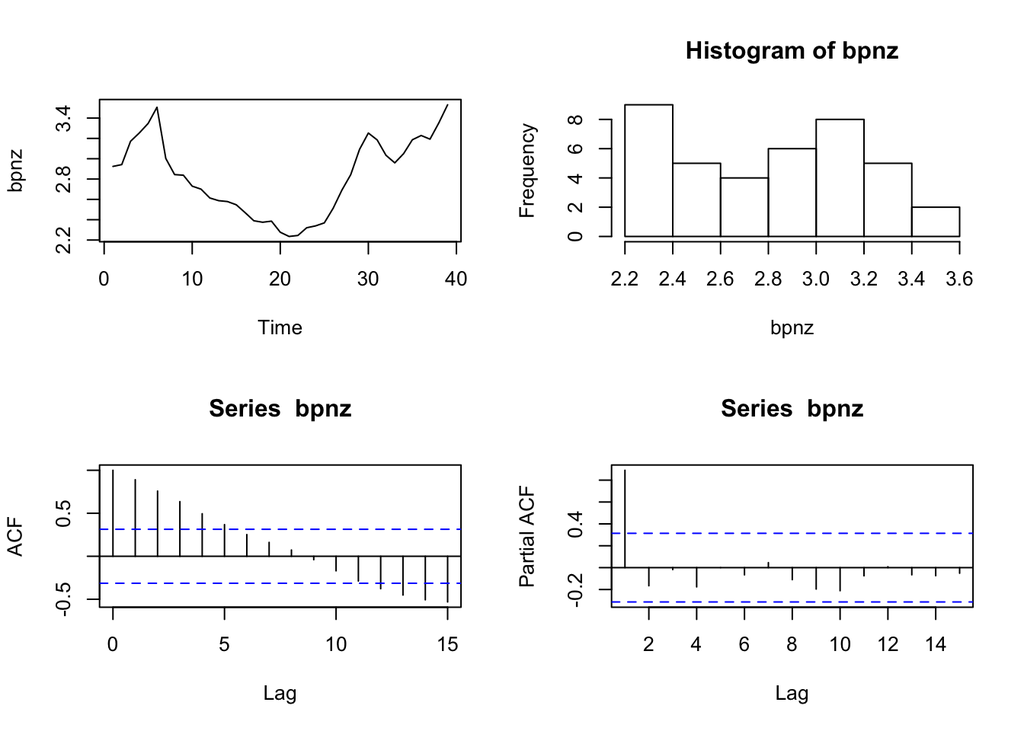

```r
par(mfrow=c(2,2))
plot(bpnz)
hist(bpnz)
acf(bpnz)
pacf(bpnz)
```

Observations: